# 2. A Tidyverse Primer

Russ Conte

2022-05-25

Start by loading the required packages in two lines of code:

```r
Packages <- c("tidyverse", "caret")
lapply(Packages, library, character = TRUE)
```

```
## [[1]]
##  [1] "forcats"   "stringr"   "dplyr"     "purrr"     "readr"     "tidyr"
##  [7] "tibble"    "ggplot2"   "tidyverse" "stats"     "graphics"  "grDevices"
## [13] "utils"     "datasets"  "methods"   "base"
##
## [[2]]
##  [1] "caret"     "lattice"   "forcats"   "stringr"   "dplyr"     "purrr"
##  [7] "readr"     "tidyr"     "tibble"    "ggplot2"   "tidyverse" "stats"
## [13] "graphics"  "grDevices" "utils"     "datasets"  "methods"   "base"
```

Start with code for multi-core processing

```r
library(doParallel)
cl <- makePSOCKcluster(10)
registerDoParallel(cl)
```

## 2.1 Tidyverse Principles

### 2.1.1 Design for Humans

The variable names used here are “unquoted”; many traditional R functions require character strings to specify variables, but tidyverse functions take unquoted names or *selector functions*. The selectors allow one or more readable rules that are applied to call him names. For example, `ends_with("t")` would select the `drat` and `wt` columns of the `mtcars` data frame.

```r
mtcars %>%
  select(ends_with("t"))
```

```
##                     drat    wt
## Mazda RX4           3.90 2.620
## Mazda RX4 Wag       3.90 2.875
## Datsun 710          3.85 2.320
## Hornet 4 Drive      3.08 3.215
## Hornet Sportabout   3.15 3.440
## Valiant             2.76 3.460
## Duster 360          3.21 3.570
## Merc 240D           3.69 3.190
## Merc 230            3.92 3.150
## Merc 280            3.92 3.440
## Merc 280C           3.92 3.440
## Merc 450SE          3.07 4.070
## Merc 450SL          3.07 3.730
## Merc 450SLC         3.07 3.780
## Cadillac Fleetwood  2.93 5.250
## Lincoln Continental 3.00 5.424
## Chrysler Imperial   3.23 5.345
## Fiat 128            4.08 2.200
## Honda Civic         4.93 1.615
## Toyota Corolla      4.22 1.835
## Toyota Corona       3.70 2.465
## Dodge Challenger    2.76 3.520
## AMC Javelin         3.15 3.435
## Camaro Z28          3.73 3.840
## Pontiac Firebird    3.08 3.845
## Fiat X1-9           4.08 1.935
## Porsche 914-2       4.43 2.140
## Lotus Europa        3.77 1.513
## Ford Pantera L      4.22 3.170
## Ferrari Dino        3.62 2.770
## Maserati Bora       3.54 3.570
## Volvo 142E          4.11 2.780
```

### 2.1.2 Reuse existing data structures

Whenever possible, functions should avoid returning a novel data structure. If the results are conducive to an existing data structure, it should be used. This reduces the cognitive load when using software; no additional syntax or methods are required.

As an example, the hour sample package can be used to create*re-samples*of a data set, such as cross-validation or the bootstrap (described in chapter 10). The resampling functions return a table with a column called `splits` of objects that defined the resample data sets. Three bootstrap samples of a data set might look like:

```r
boot_samp <- rsample::bootstraps(mtcars,times = 3)
boot_samp
```

```
## # Bootstrap sampling
## # A tibble: 3 × 2
##   splits          id
##   <list>          <chr>
## 1 <split [32/12]> Bootstrap1
## 2 <split [32/12]> Bootstrap2
## 3 <split [32/13]> Bootstrap3
```

```r
class(boot_samp)
```

```
## [1] "bootstraps" "rset"       "tbl_df"     "tbl"        "data.frame"
```

With this approach, vector-based functions can be used with these columns, such as `vapply()` or `purr::map()`. This `boot_samp` object has multiple classes but inherits methods for data frames (`"data.frame"`) and tibbles (`'tbl_df"`). Additionally, new columns can be added to the results without affecting the class of the data. This is much easier and more versitile for users to work with than a completely new object type that does not make its data structure obvious.

## 2.1.3 Design for the pipe and functional programming

The **magrittr** pipe operator (‘%>%’) is a tool for chaining together a sequence of R functions. To demonstrate, consider the following commands that sort a data frame and then retain the first ten rows:

```r
small_mtcars <- arrange(mtcars, gear)
small_mtcars <- slice(small_mtcars, 1:10)

# or more compactly:

small_mtcars <- slice(arrange(mtcars, gear), 1:10)
```

The pipe operator substitutes the value of the left-hand side of the operator as the first argument to the right-hand side so we can implement the same result as before:

```r
small_mtcars <-
  mtcars %>%
  arrange(gear) %>%
  slice(1:10)

small_mtcars
```

```
##                      mpg cyl  disp  hp drat    wt  qsec vs am gear carb
## Hornet 4 Drive      21.4   6 258.0 110 3.08 3.215 19.44  1  0    3    1
## Hornet Sportabout   18.7   8 360.0 175 3.15 3.440 17.02  0  0    3    2
## Valiant             18.1   6 225.0 105 2.76 3.460 20.22  1  0    3    1
## Duster 360          14.3   8 360.0 245 3.21 3.570 15.84  0  0    3    4
## Merc 450SE          16.4   8 275.8 180 3.07 4.070 17.40  0  0    3    3
## Merc 450SL          17.3   8 275.8 180 3.07 3.730 17.60  0  0    3    3
## Merc 450SLC         15.2   8 275.8 180 3.07 3.780 18.00  0  0    3    3
## Cadillac Fleetwood  10.4   8 472.0 205 2.93 5.250 17.98  0  0    3    4
## Lincoln Continental 10.4   8 460.0 215 3.00 5.424 17.82  0  0    3    4
## Chrysler Imperial   14.7   8 440.0 230 3.23 5.345 17.42  0  0    3    4
```

The pipe version of the sequence is more readable; this weight ability increases as more operations are added to the sequence. This approach to programming works in this example because all of the functions we used to return the same data structure (a data frame) that is then used as the first document to the next function. This is by design. When possible, create functions that can be incorporated into a pipeline of operations.

If you have used **ggplot2**, this is not unlike the layering of plot components into a `ggplot` object wit th `+` operator. To make a scatter plot with a regression line, the intial `ggplot()` call is augmented with two additional operations:

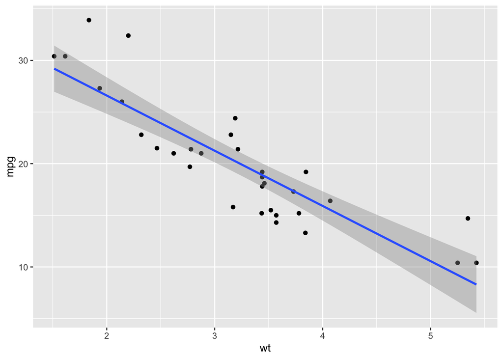

```r
ggplot(mtcars, aes(x = wt, y = mpg)) +
  geom_point() +
  geom_smooth(method = lm)
```

R has excellent tools for creating, changing, and operating on functions, making it a great language for functional programming. This approach can replace iterative loops in many situations, such as when a function returns a value without other side effects.

Let’s look at an example. Suppose you re interested in the logarithm of the ration of the fuel efficiency to the car weight.

```r
log_ratios <- map2_dbl(mtcars$mpg, mtcars$wt, ~log(.x/.y))
log_ratios
```

```
##  [1] 2.0813481 1.9884698 2.2851934 1.8955636 1.6930521 1.6546433 1.3876939
##  [8] 2.0345622 1.9793581 1.7194388 1.6437270 1.3936383 1.5342983 1.3915714
## [15] 0.6835777 0.6509723 1.0116859 2.6897011 2.9351077 2.9163705 2.1658611
## [22] 1.4823790 1.4872785 1.2422917 1.6081367 2.6467794 2.4972907 3.0003482
## [29] 1.6062784 1.9617713 1.4354846 2.0409400
```

### *For functional programming in tidy modeling, functions should be defined so that functions like `map()` can be used for iterative computations.*

## 2.2 Examples of tidyverse syntax

Standard data frames enable *partial matching* of arguments so that code using only a portion of the column names still works. Tibbles prevent this from happening since it can lead to accidental errors:

```r
df <- data.frame(`variable 1` = 1:2, two = 3:4, check.names = FALSE)
df$tw
```

```
## [1] 3 4
```

```r
tbbl <- tibble(`variable 1` = 1:2, two = 3:4)
tbbl$tw
```

[output not shown]

Tibble also prevent one of the most common R errors: Dropping dimensions. If a standard data frame subsets the columns down to a single column, the object is converted to a vector. Tibbles never do this:

```r
df[,"two"]
```

```
## [1] 3 4
```

```r
tbbl[,"two"]
```

```
## # A tibble: 2 × 1
##     two
##   <int>
## 1     3
## 2     4
```

To demonstrate some syntax, let’s use tidyverse functions to read in data that could be used in modeling. The dat set comes form the city of Chicago’s data portal and contains daily ridership data for the city’s elevated train stations. The data set has columns for:

- The station identifier (numeric)
- The station name (character)
- The date (character in `mm/dd/yyyy` format)
- The day of the week (character)
- The number of riders (numeric)
1. The tidyverse package **readr** will read the data from the source website and convert them into a tibble. To do this, the `read_csv()` function can determine the type of data by reading an initial number of rows. Alternatively, if the column names and types are already know, a column specification can be created in R and passed to `read_csv()`.
2. Filter the data to eliminate a few columns that are not needed (such as station ID) and change the column `stationname` to `station`. The function `select()` is used for this. When filtering, use either the column names, or a **dplyr** selector function. When selecting names, a new variable name can be declared using the argument format `new_name old_name`
3. Convert the date field to the R date format using the`mdy()` function from the **lubridate** package. We also convert the ridership numbers to thousands. Both of these computations are executed using the `dplyr::mutate()` function/
4. Use the maximum number of rides for each station and day combination. This mitigates the issue of a small number of days that have more than one record of ridership numbers at certain stations. We group the ridershp data by station and day, and then summarize within each of the 1999 unique combinations with the maximum statistic.

The tidyverse code for these steps is:

```r
library(lubridate)
url <- "https://data.cityofchicago.org/api/views/5neh-572f/rows.csv?accessType=DOWNLOAD&bom=true&format=true"

all_stations <-
  # step 1: Read in the data.
  read_csv(url) %>%
  # step 2: Filter columns and rename stationname
  select(station = stationname, date, rides) %>%
    # Step 3: Convert the character date field to a date encoding.
    # Also, put the data in units of 1,000 rides
    mutate(date = mdy(date), rides = rides/1000) %>%
    # Step 4: Summarize the multiple records using the maximum
    group_by(date, station) %>%
    summarise(rides = max(rides), .groups = "drop")
```

## 2.3 Chapter Summary

REFERENCES

Wickham, H, M Averick, J Bryan, W Chang, L McGowan, R François, G Grolemund, et al. 2019. “Welcome to the Tidyverse.” Journal of Open Source Software 4 (43). Wickham, H, and G Grolemund. 2016. R for Data Science: Import, Tidy, Transform, Visualize, and Model Data. O’Reilly Media, Inc.